# Optimal Treatment Analysis

## Outcome Variable

**Outcome Variable:** ever_stunted

## Predictor Variables

**Intervention Variable:** feducyrs

**Adjustment Set:**

- arm
- W_mage
- meducyrs
- hhwealth_quart
- W_mhtcm
- W_gagebrth
- W_birthwt
- W_birthlen
- W_nrooms
- W_nchldlt5
- impfloor
- impsan
- safeh20
- delta_W_mage
- delta_meducyrs
- delta_hhwealth_quart
- delta_W_mhtcm
- delta_W_gagebrth
- delta_W_birthwt
- delta_W_birthlen
- delta_W_nrooms
- delta_W_nchldlt5
- delta_impfloor
- delta_impsan
- delta_safeh20

## Stratifying Variables

The analysis was stratified on these variable(s):

- agecat
- studyid
- country

## Data Summary

| agecat | studyid | country | feducyrs | ever_stunted | n_cell | n |
| --- | --- | --- | --- | --- | --- | --- |
| 0-24 months | ki0047075b-MAL-ED | BANGLADESH | Low | 0 | 15 | 149 |
| 0-24 months | ki0047075b-MAL-ED | BANGLADESH | Low | 1 | 25 | 149 |
| 0-24 months | ki0047075b-MAL-ED | BANGLADESH | Medium | 0 | 20 | 149 |
| 0-24 months | ki0047075b-MAL-ED | BANGLADESH | Medium | 1 | 35 | 149 |
| 0-24 months | ki0047075b-MAL-ED | BANGLADESH | High | 0 | 31 | 149 |
| 0-24 months | ki0047075b-MAL-ED | BANGLADESH | High | 1 | 23 | 149 |
| 0-24 months | ki0047075b-MAL-ED | INDIA | Low | 0 | 28 | 147 |
| 0-24 months | ki0047075b-MAL-ED | INDIA | Low | 1 | 31 | 147 |
| 0-24 months | ki0047075b-MAL-ED | INDIA | Medium | 0 | 18 | 147 |
| 0-24 months | ki0047075b-MAL-ED | INDIA | Medium | 1 | 26 | 147 |
| 0-24 months | ki0047075b-MAL-ED | INDIA | High | 0 | 18 | 147 |
| 0-24 months | ki0047075b-MAL-ED | INDIA | High | 1 | 26 | 147 |
| 0-24 months | ki0047075b-MAL-ED | NEPAL | Low | 0 | 16 | 98 |
| 0-24 months | ki0047075b-MAL-ED | NEPAL | Low | 1 | 12 | 98 |
| 0-24 months | ki0047075b-MAL-ED | NEPAL | Medium | 0 | 15 | 98 |
| 0-24 months | ki0047075b-MAL-ED | NEPAL | Medium | 1 | 13 | 98 |
| 0-24 months | ki0047075b-MAL-ED | NEPAL | High | 0 | 32 | 98 |
| 0-24 months | ki0047075b-MAL-ED | NEPAL | High | 1 | 10 | 98 |
| 0-24 months | ki0047075b-MAL-ED | PERU | Low | 0 | 28 | 250 |
| 0-24 months | ki0047075b-MAL-ED | PERU | Low | 1 | 41 | 250 |
| 0-24 months | ki0047075b-MAL-ED | PERU | Medium | 0 | 20 | 250 |
| 0-24 months | ki0047075b-MAL-ED | PERU | Medium | 1 | 41 | 250 |
| 0-24 months | ki0047075b-MAL-ED | PERU | High | 0 | 45 | 250 |
| 0-24 months | ki0047075b-MAL-ED | PERU | High | 1 | 75 | 250 |
| 0-24 months | ki0047075b-MAL-ED | SOUTH AFRICA | Low | 0 | 18 | 110 |
| 0-24 months | ki0047075b-MAL-ED | SOUTH AFRICA | Low | 1 | 19 | 110 |
| 0-24 months | ki0047075b-MAL-ED | SOUTH AFRICA | Medium | 0 | 11 | 110 |
| 0-24 months | ki0047075b-MAL-ED | SOUTH AFRICA | Medium | 1 | 19 | 110 |
| 0-24 months | ki0047075b-MAL-ED | SOUTH AFRICA | High | 0 | 15 | 110 |
| 0-24 months | ki0047075b-MAL-ED | SOUTH AFRICA | High | 1 | 28 | 110 |

[output cut: 330 more lines]

The following strata were considered:

- agecat: 0-24 months, studyid: ki0047075b-MAL-ED, country: BANGLADESH
- agecat: 0-24 months, studyid: ki0047075b-MAL-ED, country: INDIA
- agecat: 0-24 months, studyid: ki0047075b-MAL-ED, country: NEPAL
- agecat: 0-24 months, studyid: ki0047075b-MAL-ED, country: PERU
- agecat: 0-24 months, studyid: ki0047075b-MAL-ED, country: SOUTH AFRICA
- agecat: 0-24 months, studyid: ki0047075b-MAL-ED, country: TANZANIA, UNITED REPUBLIC OF
- agecat: 0-24 months, studyid: ki1000304b-SAS-CompFeed, country: INDIA
- agecat: 0-24 months, studyid: ki1000304b-SAS-FoodSuppl, country: INDIA
- agecat: 0-24 months, studyid: ki1017093b-PROVIDE, country: BANGLADESH
- agecat: 0-24 months, studyid: ki1017093c-NIH-Crypto, country: BANGLADESH
- agecat: 0-24 months, studyid: ki1066203-TanzaniaChild2, country: TANZANIA, UNITED REPUBLIC OF
- agecat: 0-24 months, studyid: ki1113344-GMS-Nepal, country: NEPAL
- agecat: 0-24 months, studyid: ki1119695-PROBIT, country: BELARUS
- agecat: 0-24 months, studyid: ki1126311-ZVITAMBO, country: ZIMBABWE
- agecat: 0-24 months, studyid: ki1135781-COHORTS, country: GUATEMALA
- agecat: 0-24 months, studyid: ki1135781-COHORTS, country: INDIA
- agecat: 0-24 months, studyid: ki1135781-COHORTS, country: PHILIPPINES
- agecat: 0-24 months, studyid: ki1148112-LCNI-5, country: MALAWI
- agecat: 0-24 months, studyid: kiGH5241-JiVitA-3, country: BANGLADESH
- agecat: 0-24 months, studyid: kiGH5241-JiVitA-4, country: BANGLADESH
- agecat: 0-6 months, studyid: ki0047075b-MAL-ED, country: BANGLADESH
- agecat: 0-6 months, studyid: ki0047075b-MAL-ED, country: INDIA
- agecat: 0-6 months, studyid: ki0047075b-MAL-ED, country: NEPAL
- agecat: 0-6 months, studyid: ki0047075b-MAL-ED, country: PERU
- agecat: 0-6 months, studyid: ki0047075b-MAL-ED, country: SOUTH AFRICA
- agecat: 0-6 months, studyid: ki0047075b-MAL-ED, country: TANZANIA, UNITED REPUBLIC OF
- agecat: 0-6 months, studyid: ki1000304b-SAS-CompFeed, country: INDIA
- agecat: 0-6 months, studyid: ki1000304b-SAS-FoodSuppl, country: INDIA
- agecat: 0-6 months, studyid: ki1017093b-PROVIDE, country: BANGLADESH
- agecat: 0-6 months, studyid: ki1017093c-NIH-Crypto, country: BANGLADESH
- agecat: 0-6 months, studyid: ki1066203-TanzaniaChild2, country: TANZANIA, UNITED REPUBLIC OF
- agecat: 0-6 months, studyid: ki1113344-GMS-Nepal, country: NEPAL
- agecat: 0-6 months, studyid: ki1119695-PROBIT, country: BELARUS
- agecat: 0-6 months, studyid: ki1126311-ZVITAMBO, country: ZIMBABWE
- agecat: 0-6 months, studyid: ki1135781-COHORTS, country: GUATEMALA
- agecat: 0-6 months, studyid: ki1135781-COHORTS, country: INDIA
- agecat: 0-6 months, studyid: ki1135781-COHORTS, country: PHILIPPINES
- agecat: 0-6 months, studyid: ki1148112-LCNI-5, country: MALAWI
- agecat: 0-6 months, studyid: kiGH5241-JiVitA-3, country: BANGLADESH
- agecat: 0-6 months, studyid: kiGH5241-JiVitA-4, country: BANGLADESH
- agecat: 6-24 months, studyid: ki0047075b-MAL-ED, country: BANGLADESH
- agecat: 6-24 months, studyid: ki0047075b-MAL-ED, country: INDIA
- agecat: 6-24 months, studyid: ki0047075b-MAL-ED, country: NEPAL
- agecat: 6-24 months, studyid: ki0047075b-MAL-ED, country: PERU
- agecat: 6-24 months, studyid: ki0047075b-MAL-ED, country: SOUTH AFRICA
- agecat: 6-24 months, studyid: ki0047075b-MAL-ED, country: TANZANIA, UNITED REPUBLIC OF
- agecat: 6-24 months, studyid: ki1000304b-SAS-CompFeed, country: INDIA
- agecat: 6-24 months, studyid: ki1000304b-SAS-FoodSuppl, country: INDIA
- agecat: 6-24 months, studyid: ki1017093b-PROVIDE, country: BANGLADESH
- agecat: 6-24 months, studyid: ki1017093c-NIH-Crypto, country: BANGLADESH
- agecat: 6-24 months, studyid: ki1066203-TanzaniaChild2, country: TANZANIA, UNITED REPUBLIC OF
- agecat: 6-24 months, studyid: ki1113344-GMS-Nepal, country: NEPAL
- agecat: 6-24 months, studyid: ki1119695-PROBIT, country: BELARUS
- agecat: 6-24 months, studyid: ki1126311-ZVITAMBO, country: ZIMBABWE
- agecat: 6-24 months, studyid: ki1135781-COHORTS, country: GUATEMALA
- agecat: 6-24 months, studyid: ki1135781-COHORTS, country: INDIA
- agecat: 6-24 months, studyid: ki1135781-COHORTS, country: PHILIPPINES
- agecat: 6-24 months, studyid: ki1148112-LCNI-5, country: MALAWI
- agecat: 6-24 months, studyid: kiGH5241-JiVitA-3, country: BANGLADESH
- agecat: 6-24 months, studyid: kiGH5241-JiVitA-4, country: BANGLADESH

### Dropped Strata

Some strata were dropped due to rare outcomes:

- agecat: 0-24 months, studyid: ki0047075b-MAL-ED, country: TANZANIA, UNITED REPUBLIC OF
- agecat: 0-6 months, studyid: ki0047075b-MAL-ED, country: NEPAL
- agecat: 6-24 months, studyid: ki0047075b-MAL-ED, country: NEPAL
- agecat: 6-24 months, studyid: ki0047075b-MAL-ED, country: TANZANIA, UNITED REPUBLIC OF

## Methods Detail

We’re interested in the causal parameters $E[Y_a]$ for all values of $a \in \mathcal{A}$. These parameters represent the mean outcome if, possibly contrary to fact, we intervened to set all units to have $A=a$. Under the randomization and positivity assumptions, these are identified by the statistical parameters $\psi_a=E_W[E_{Y|A,W}(Y|A=a,W)]$. In addition, we’re interested in the mean of $Y$, $E[Y]$ under no intervention (the observed mean). We will estimate these parameters by using SuperLearner to fit the relevant likelihood factors – $E_{Y|A,W}(Y|A=a,W)$ and $p(A=a|W)$, and then updating our likelihood fit using a joint TMLE.

For unadjusted analyses ($W=\{\}$), initial likelihoods were estimated using Lrnr_glm to estimate the simple $E(Y|A)$ and Lrnr_mean to estimate $p(A)$. For adjusted analyses, a small library containing Lrnr_glmnet, Lrnr_xgboost, and Lrnr_mean was used.

Having estimated these parameters, we will then use the delta method to estimate relative risks and attributable risks relative to a prespecified baseline level of $A$.

# Results Detail

## Results Plots

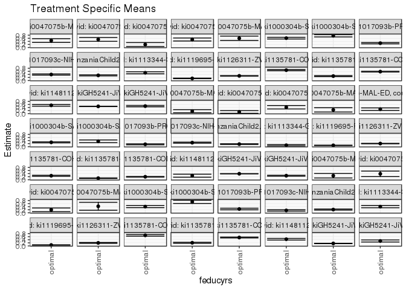

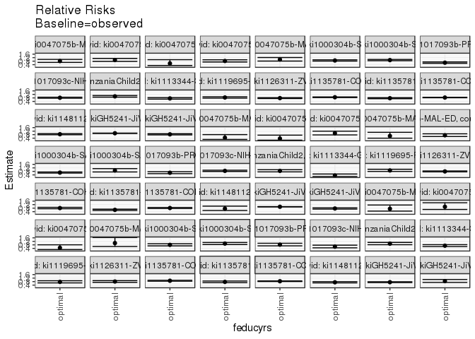

## Results Table

### Parameter: TSM

| agecat | studyid | country | intervention_level | baseline_level | estimate | ci_lower | ci_upper |
| --- | --- | --- | --- | --- | --- | --- | --- |
| 0-24 months | ki0047075b-MAL-ED | BANGLADESH | optimal | NA | 0.4509565 | 0.3301735 | 0.5717394 |
| 0-24 months | ki0047075b-MAL-ED | INDIA | optimal | NA | 0.5259660 | 0.4027606 | 0.6491714 |
| 0-24 months | ki0047075b-MAL-ED | NEPAL | optimal | NA | 0.1919397 | 0.0634707 | 0.3204087 |
| 0-24 months | ki0047075b-MAL-ED | PERU | optimal | NA | 0.5193061 | 0.4222041 | 0.6164082 |
| 0-24 months | ki0047075b-MAL-ED | SOUTH AFRICA | optimal | NA | 0.5997643 | 0.4588268 | 0.7407018 |
| 0-24 months | ki1000304b-SAS-CompFeed | INDIA | optimal | NA | 0.6079712 | 0.5510673 | 0.6648752 |
| 0-24 months | ki1000304b-SAS-FoodSuppl | INDIA | optimal | NA | 0.7618513 | 0.6875574 | 0.8361451 |
| 0-24 months | ki1017093b-PROVIDE | BANGLADESH | optimal | NA | 0.2808877 | 0.2380558 | 0.3237196 |
| 0-24 months | ki1017093c-NIH-Crypto | BANGLADESH | optimal | NA | 0.3930221 | 0.3543116 | 0.4317326 |
| 0-24 months | ki1066203-TanzaniaChild2 | TANZANIA, UNITED REPUBLIC OF | optimal | NA | 0.3384966 | 0.3033075 | 0.3736858 |
| 0-24 months | ki1113344-GMS-Nepal | NEPAL | optimal | NA | 0.5050943 | 0.4381093 | 0.5720794 |
| 0-24 months | ki1119695-PROBIT | BELARUS | optimal | NA | 0.1402265 | 0.1224181 | 0.1580349 |
| 0-24 months | ki1126311-ZVITAMBO | ZIMBABWE | optimal | NA | 0.3056426 | 0.2868640 | 0.3244212 |
| 0-24 months | ki1135781-COHORTS | GUATEMALA | optimal | NA | 0.6765242 | 0.6398124 | 0.7132361 |
| 0-24 months | ki1135781-COHORTS | INDIA | optimal | NA | 0.2913534 | 0.2621056 | 0.3206012 |
| 0-24 months | ki1135781-COHORTS | PHILIPPINES | optimal | NA | 0.5817695 | 0.5564565 | 0.6070826 |
| 0-24 months | ki1148112-LCNI-5 | MALAWI | optimal | NA | 0.5401209 | 0.4846558 | 0.5955860 |
| 0-24 months | kiGH5241-JiVitA-3 | BANGLADESH | optimal | NA | 0.4721723 | 0.4613747 | 0.4829698 |
| 0-24 months | kiGH5241-JiVitA-4 | BANGLADESH | optimal | NA | 0.4891673 | 0.4454964 | 0.5328383 |
| 0-6 months | ki0047075b-MAL-ED | BANGLADESH | optimal | NA | 0.1573758 | 0.0563349 | 0.2584167 |
| 0-6 months | ki0047075b-MAL-ED | INDIA | optimal | NA | 0.1109468 | 0.0229626 | 0.1989310 |
| 0-6 months | ki0047075b-MAL-ED | PERU | optimal | NA | 0.4138485 | 0.3024124 | 0.5252846 |
| 0-6 months | ki0047075b-MAL-ED | SOUTH AFRICA | optimal | NA | 0.2439867 | 0.1051101 | 0.3828634 |
| 0-6 months | ki0047075b-MAL-ED | TANZANIA, UNITED REPUBLIC OF | optimal | NA | 0.2917105 | 0.2092033 | 0.3742176 |
| 0-6 months | ki1000304b-SAS-CompFeed | INDIA | optimal | NA | 0.2846834 | 0.2523373 | 0.3170296 |
| 0-6 months | ki1000304b-SAS-FoodSuppl | INDIA | optimal | NA | 0.3535664 | 0.2670971 | 0.4400357 |
| 0-6 months | ki1017093b-PROVIDE | BANGLADESH | optimal | NA | 0.1563709 | 0.1227531 | 0.1899887 |
| 0-6 months | ki1017093c-NIH-Crypto | BANGLADESH | optimal | NA | 0.2624535 | 0.2279798 | 0.2969272 |
| 0-6 months | ki1066203-TanzaniaChild2 | TANZANIA, UNITED REPUBLIC OF | optimal | NA | 0.1674517 | 0.1408178 | 0.1940857 |
| 0-6 months | ki1113344-GMS-Nepal | NEPAL | optimal | NA | 0.0936489 | 0.0516764 | 0.1356214 |
| 0-6 months | ki1119695-PROBIT | BELARUS | optimal | NA | 0.0871247 | 0.0736272 | 0.1006223 |
| 0-6 months | ki1126311-ZVITAMBO | ZIMBABWE | optimal | NA | 0.2041605 | 0.1892635 | 0.2190575 |
| 0-6 months | ki1135781-COHORTS | GUATEMALA | optimal | NA | 0.2628835 | 0.2304913 | 0.2952758 |
| 0-6 months | ki1135781-COHORTS | INDIA | optimal | NA | 0.1028067 | 0.0854388 | 0.1201747 |
| 0-6 months | ki1135781-COHORTS | PHILIPPINES | optimal | NA | 0.1940277 | 0.1755374 | 0.2125180 |
| 0-6 months | ki1148112-LCNI-5 | MALAWI | optimal | NA | 0.2645906 | 0.1663867 | 0.3627944 |
| 0-6 months | kiGH5241-JiVitA-3 | BANGLADESH | optimal | NA | 0.3915100 | 0.3816885 | 0.4013315 |
| 0-6 months | kiGH5241-JiVitA-4 | BANGLADESH | optimal | NA | 0.2648036 | 0.2349092 | 0.2946979 |
| 6-24 months | ki0047075b-MAL-ED | BANGLADESH | optimal | NA | 0.2625575 | 0.1169352 | 0.4081797 |
| 6-24 months | ki0047075b-MAL-ED | INDIA | optimal | NA | 0.3861246 | 0.2061909 | 0.5660582 |
| 6-24 months | ki0047075b-MAL-ED | PERU | optimal | NA | 0.1955494 | 0.0759305 | 0.3151682 |
| 6-24 months | ki0047075b-MAL-ED | SOUTH AFRICA | optimal | NA | 0.4269753 | 0.1681662 | 0.6857844 |
| 6-24 months | ki1000304b-SAS-CompFeed | INDIA | optimal | NA | 0.4054502 | 0.3368989 | 0.4740015 |
| 6-24 months | ki1000304b-SAS-FoodSuppl | INDIA | optimal | NA | 0.7157036 | 0.6100241 | 0.8213831 |
| 6-24 months | ki1017093b-PROVIDE | BANGLADESH | optimal | NA | 0.2486362 | 0.1948631 | 0.3024092 |
| 6-24 months | ki1017093c-NIH-Crypto | BANGLADESH | optimal | NA | 0.1571655 | 0.1104560 | 0.2038749 |
| 6-24 months | ki1066203-TanzaniaChild2 | TANZANIA, UNITED REPUBLIC OF | optimal | NA | 0.2126284 | 0.1783005 | 0.2469562 |
| 6-24 months | ki1113344-GMS-Nepal | NEPAL | optimal | NA | 0.4027513 | 0.3302646 | 0.4752380 |
| 6-24 months | ki1119695-PROBIT | BELARUS | optimal | NA | 0.0581795 | 0.0440856 | 0.0722734 |
| 6-24 months | ki1126311-ZVITAMBO | ZIMBABWE | optimal | NA | 0.1963206 | 0.1710725 | 0.2215688 |
| 6-24 months | ki1135781-COHORTS | GUATEMALA | optimal | NA | 0.6872448 | 0.6351999 | 0.7392896 |
| 6-24 months | ki1135781-COHORTS | INDIA | optimal | NA | 0.2047276 | 0.1732951 | 0.2361600 |
| 6-24 months | ki1135781-COHORTS | PHILIPPINES | optimal | NA | 0.5459759 | 0.5163187 | 0.5756331 |
| 6-24 months | ki1148112-LCNI-5 | MALAWI | optimal | NA | 0.4349308 | 0.3795203 | 0.4903413 |
| 6-24 months | kiGH5241-JiVitA-3 | BANGLADESH | optimal | NA | 0.1600545 | 0.1473659 | 0.1727431 |
| 6-24 months | kiGH5241-JiVitA-4 | BANGLADESH | optimal | NA | 0.3206567 | 0.2532400 | 0.3880733 |

### Parameter: E(Y)

| agecat | studyid | country | intervention_level | baseline_level | estimate | ci_lower | ci_upper |
| --- | --- | --- | --- | --- | --- | --- | --- |
| 0-24 months | ki0047075b-MAL-ED | BANGLADESH | observed | NA | 0.5557976 | 0.4757696 | 0.6358256 |
| 0-24 months | ki0047075b-MAL-ED | INDIA | observed | NA | 0.5653723 | 0.4849487 | 0.6457958 |
| 0-24 months | ki0047075b-MAL-ED | NEPAL | observed | NA | 0.3547604 | 0.2594061 | 0.4501148 |
| 0-24 months | ki0047075b-MAL-ED | PERU | observed | NA | 0.6321495 | 0.5721152 | 0.6921839 |
| 0-24 months | ki0047075b-MAL-ED | SOUTH AFRICA | observed | NA | 0.6039754 | 0.5120066 | 0.6959442 |
| 0-24 months | ki1000304b-SAS-CompFeed | INDIA | observed | NA | 0.6930041 | 0.6526993 | 0.7333090 |
| 0-24 months | ki1000304b-SAS-FoodSuppl | INDIA | observed | NA | 0.8273632 | 0.7911215 | 0.8636049 |
| 0-24 months | ki1017093b-PROVIDE | BANGLADESH | observed | NA | 0.4463100 | 0.4095652 | 0.4830548 |
| 0-24 months | ki1017093c-NIH-Crypto | BANGLADESH | observed | NA | 0.4798224 | 0.4442402 | 0.5154046 |
| 0-24 months | ki1066203-TanzaniaChild2 | TANZANIA, UNITED REPUBLIC OF | observed | NA | 0.3468161 | 0.3277049 | 0.3659273 |
| 0-24 months | ki1113344-GMS-Nepal | NEPAL | observed | NA | 0.6806712 | 0.6432103 | 0.7181321 |
| 0-24 months | ki1119695-PROBIT | BELARUS | observed | NA | 0.1651932 | 0.1462684 | 0.1841180 |
| 0-24 months | ki1126311-ZVITAMBO | ZIMBABWE | observed | NA | 0.3931993 | 0.3850187 | 0.4013799 |
| 0-24 months | ki1135781-COHORTS | GUATEMALA | observed | NA | 0.7736177 | 0.7501801 | 0.7970553 |
| 0-24 months | ki1135781-COHORTS | INDIA | observed | NA | 0.3811697 | 0.3561772 | 0.4061623 |
| 0-24 months | ki1135781-COHORTS | PHILIPPINES | observed | NA | 0.6904189 | 0.6735239 | 0.7073140 |
| 0-24 months | ki1148112-LCNI-5 | MALAWI | observed | NA | 0.6358395 | 0.6027679 | 0.6689111 |
| 0-24 months | kiGH5241-JiVitA-3 | BANGLADESH | observed | NA | 0.4921570 | 0.4842516 | 0.5000624 |
| 0-24 months | kiGH5241-JiVitA-4 | BANGLADESH | observed | NA | 0.5847918 | 0.5625826 | 0.6070009 |
| 0-6 months | ki0047075b-MAL-ED | BANGLADESH | observed | NA | 0.3479513 | 0.2715098 | 0.4243928 |
| 0-6 months | ki0047075b-MAL-ED | INDIA | observed | NA | 0.3114166 | 0.2366580 | 0.3861751 |
| 0-6 months | ki0047075b-MAL-ED | PERU | observed | NA | 0.4304076 | 0.3689511 | 0.4918642 |
| 0-6 months | ki0047075b-MAL-ED | SOUTH AFRICA | observed | NA | 0.3743119 | 0.2835385 | 0.4650853 |
| 0-6 months | ki0047075b-MAL-ED | TANZANIA, UNITED REPUBLIC OF | observed | NA | 0.4019115 | 0.3357840 | 0.4680391 |
| 0-6 months | ki1000304b-SAS-CompFeed | INDIA | observed | NA | 0.4285091 | 0.4004578 | 0.4565604 |
| 0-6 months | ki1000304b-SAS-FoodSuppl | INDIA | observed | NA | 0.3909208 | 0.3440065 | 0.4378351 |
| 0-6 months | ki1017093b-PROVIDE | BANGLADESH | observed | NA | 0.2415765 | 0.2099804 | 0.2731726 |
| 0-6 months | ki1017093c-NIH-Crypto | BANGLADESH | observed | NA | 0.3048091 | 0.2720994 | 0.3375188 |
| 0-6 months | ki1066203-TanzaniaChild2 | TANZANIA, UNITED REPUBLIC OF | observed | NA | 0.1951879 | 0.1792730 | 0.2111028 |
| 0-6 months | ki1113344-GMS-Nepal | NEPAL | observed | NA | 0.2836633 | 0.2478206 | 0.3195060 |
| 0-6 months | ki1119695-PROBIT | BELARUS | observed | NA | 0.0958172 | 0.0828141 | 0.1088202 |
| 0-6 months | ki1126311-ZVITAMBO | ZIMBABWE | observed | NA | 0.2568302 | 0.2495150 | 0.2641454 |
| 0-6 months | ki1135781-COHORTS | GUATEMALA | observed | NA | 0.3257319 | 0.2971001 | 0.3543638 |
| 0-6 months | ki1135781-COHORTS | INDIA | observed | NA | 0.1706068 | 0.1513495 | 0.1898642 |
| 0-6 months | ki1135781-COHORTS | PHILIPPINES | observed | NA | 0.2384672 | 0.2229070 | 0.2540274 |
| 0-6 months | ki1148112-LCNI-5 | MALAWI | observed | NA | 0.3566563 | 0.2991227 | 0.4141900 |
| 0-6 months | kiGH5241-JiVitA-3 | BANGLADESH | observed | NA | 0.4095803 | 0.4020419 | 0.4171187 |
| 0-6 months | kiGH5241-JiVitA-4 | BANGLADESH | observed | NA | 0.3496078 | 0.3284891 | 0.3707265 |
| 6-24 months | ki0047075b-MAL-ED | BANGLADESH | observed | NA | 0.3592522 | 0.2589918 | 0.4595125 |
| 6-24 months | ki0047075b-MAL-ED | INDIA | observed | NA | 0.4043173 | 0.3045784 | 0.5040562 |
| 6-24 months | ki0047075b-MAL-ED | PERU | observed | NA | 0.4220394 | 0.3339373 | 0.5101415 |
| 6-24 months | ki0047075b-MAL-ED | SOUTH AFRICA | observed | NA | 0.4254868 | 0.2983148 | 0.5526589 |
| 6-24 months | ki1000304b-SAS-CompFeed | INDIA | observed | NA | 0.5059706 | 0.4621948 | 0.5497465 |
| 6-24 months | ki1000304b-SAS-FoodSuppl | INDIA | observed | NA | 0.7573721 | 0.7033503 | 0.8113939 |
| 6-24 months | ki1017093b-PROVIDE | BANGLADESH | observed | NA | 0.3020088 | 0.2599570 | 0.3440606 |
| 6-24 months | ki1017093c-NIH-Crypto | BANGLADESH | observed | NA | 0.2633446 | 0.2249534 | 0.3017358 |
| 6-24 months | ki1066203-TanzaniaChild2 | TANZANIA, UNITED REPUBLIC OF | observed | NA | 0.2265590 | 0.2060164 | 0.2471016 |
| 6-24 months | ki1113344-GMS-Nepal | NEPAL | observed | NA | 0.5713263 | 0.5241057 | 0.6185470 |
| 6-24 months | ki1119695-PROBIT | BELARUS | observed | NA | 0.0759200 | 0.0619357 | 0.0899044 |
| 6-24 months | ki1126311-ZVITAMBO | ZIMBABWE | observed | NA | 0.2425381 | 0.2329923 | 0.2520840 |
| 6-24 months | ki1135781-COHORTS | GUATEMALA | observed | NA | 0.7644782 | 0.7354952 | 0.7934611 |
| 6-24 months | ki1135781-COHORTS | INDIA | observed | NA | 0.2667765 | 0.2415339 | 0.2920191 |
| 6-24 months | ki1135781-COHORTS | PHILIPPINES | observed | NA | 0.6484912 | 0.6275946 | 0.6693879 |
| 6-24 months | ki1148112-LCNI-5 | MALAWI | observed | NA | 0.6026179 | 0.5664556 | 0.6387802 |
| 6-24 months | kiGH5241-JiVitA-3 | BANGLADESH | observed | NA | 0.2182064 | 0.2087766 | 0.2276362 |
| 6-24 months | kiGH5241-JiVitA-4 | BANGLADESH | observed | NA | 0.3743633 | 0.3489936 | 0.3997330 |

### Parameter: RR

| agecat | studyid | country | intervention_level | baseline_level | estimate | ci_lower | ci_upper |
| --- | --- | --- | --- | --- | --- | --- | --- |
| 0-24 months | ki0047075b-MAL-ED | BANGLADESH | optimal | observed | 0.8113681 | 0.6571727 | 1.0017431 |
| 0-24 months | ki0047075b-MAL-ED | INDIA | optimal | observed | 0.9303003 | 0.7786111 | 1.1115417 |
| 0-24 months | ki0047075b-MAL-ED | NEPAL | optimal | observed | 0.5410403 | 0.3016075 | 0.9705483 |
| 0-24 months | ki0047075b-MAL-ED | PERU | optimal | observed | 0.8214926 | 0.7051398 | 0.9570444 |
| 0-24 months | ki0047075b-MAL-ED | SOUTH AFRICA | optimal | observed | 0.9930277 | 0.8118879 | 1.2145814 |
| 0-24 months | ki1000304b-SAS-CompFeed | INDIA | optimal | observed | 0.8772981 | 0.8096505 | 0.9505979 |
| 0-24 months | ki1000304b-SAS-FoodSuppl | INDIA | optimal | observed | 0.9208184 | 0.8504122 | 0.9970536 |
| 0-24 months | ki1017093b-PROVIDE | BANGLADESH | optimal | observed | 0.6293556 | 0.5586511 | 0.7090086 |
| 0-24 months | ki1017093c-NIH-Crypto | BANGLADESH | optimal | observed | 0.8190992 | 0.7641247 | 0.8780288 |
| 0-24 months | ki1066203-TanzaniaChild2 | TANZANIA, UNITED REPUBLIC OF | optimal | observed | 0.9760119 | 0.8888412 | 1.0717315 |
| 0-24 months | ki1113344-GMS-Nepal | NEPAL | optimal | observed | 0.7420533 | 0.6622769 | 0.8314395 |
| 0-24 months | ki1119695-PROBIT | BELARUS | optimal | observed | 0.8488635 | 0.7716538 | 0.9337987 |
| 0-24 months | ki1126311-ZVITAMBO | ZIMBABWE | optimal | observed | 0.7773224 | 0.7335017 | 0.8237611 |
| 0-24 months | ki1135781-COHORTS | GUATEMALA | optimal | observed | 0.8744942 | 0.8363798 | 0.9143456 |
| 0-24 months | ki1135781-COHORTS | INDIA | optimal | observed | 0.7643665 | 0.7093409 | 0.8236606 |
| 0-24 months | ki1135781-COHORTS | PHILIPPINES | optimal | observed | 0.8426327 | 0.8152844 | 0.8708984 |
| 0-24 months | ki1148112-LCNI-5 | MALAWI | optimal | observed | 0.8494610 | 0.7850958 | 0.9191032 |
| 0-24 months | kiGH5241-JiVitA-3 | BANGLADESH | optimal | observed | 0.9593937 | 0.9429016 | 0.9761741 |
| 0-24 months | kiGH5241-JiVitA-4 | BANGLADESH | optimal | observed | 0.8364812 | 0.7718789 | 0.9064903 |
| 0-6 months | ki0047075b-MAL-ED | BANGLADESH | optimal | observed | 0.4522926 | 0.2544633 | 0.8039219 |
| 0-6 months | ki0047075b-MAL-ED | INDIA | optimal | observed | 0.3562649 | 0.1708746 | 0.7427943 |
| 0-6 months | ki0047075b-MAL-ED | PERU | optimal | observed | 0.9615269 | 0.7705467 | 1.1998414 |
| 0-6 months | ki0047075b-MAL-ED | SOUTH AFRICA | optimal | observed | 0.6518274 | 0.3991015 | 1.0645890 |
| 0-6 months | ki0047075b-MAL-ED | TANZANIA, UNITED REPUBLIC OF | optimal | observed | 0.7258076 | 0.5862601 | 0.8985716 |
| 0-6 months | ki1000304b-SAS-CompFeed | INDIA | optimal | observed | 0.6643580 | 0.6072879 | 0.7267913 |
| 0-6 months | ki1000304b-SAS-FoodSuppl | INDIA | optimal | observed | 0.9044450 | 0.7340016 | 1.1144674 |
| 0-6 months | ki1017093b-PROVIDE | BANGLADESH | optimal | observed | 0.6472935 | 0.5467079 | 0.7663852 |
| 0-6 months | ki1017093c-NIH-Crypto | BANGLADESH | optimal | observed | 0.8610422 | 0.7906606 | 0.9376889 |
| 0-6 months | ki1066203-TanzaniaChild2 | TANZANIA, UNITED REPUBLIC OF | optimal | observed | 0.8579002 | 0.7425244 | 0.9912035 |
| 0-6 months | ki1113344-GMS-Nepal | NEPAL | optimal | observed | 0.3301411 | 0.2162273 | 0.5040675 |
| 0-6 months | ki1119695-PROBIT | BELARUS | optimal | observed | 0.9092811 | 0.7940660 | 1.0412134 |
| 0-6 months | ki1126311-ZVITAMBO | ZIMBABWE | optimal | observed | 0.7949241 | 0.7430684 | 0.8503987 |
| 0-6 months | ki1135781-COHORTS | GUATEMALA | optimal | observed | 0.8070549 | 0.7313104 | 0.8906445 |
| 0-6 months | ki1135781-COHORTS | INDIA | optimal | observed | 0.6025945 | 0.5349717 | 0.6787652 |
| 0-6 months | ki1135781-COHORTS | PHILIPPINES | optimal | observed | 0.8136450 | 0.7559851 | 0.8757027 |
| 0-6 months | ki1148112-LCNI-5 | MALAWI | optimal | observed | 0.7418642 | 0.5353343 | 1.0280725 |
| 0-6 months | kiGH5241-JiVitA-3 | BANGLADESH | optimal | observed | 0.9558809 | 0.9383773 | 0.9737111 |
| 0-6 months | kiGH5241-JiVitA-4 | BANGLADESH | optimal | observed | 0.7574304 | 0.6888797 | 0.8328025 |
| 6-24 months | ki0047075b-MAL-ED | BANGLADESH | optimal | observed | 0.7308444 | 0.4630952 | 1.1533990 |
| 6-24 months | ki0047075b-MAL-ED | INDIA | optimal | observed | 0.9550038 | 0.6466043 | 1.4104951 |
| 6-24 months | ki0047075b-MAL-ED | PERU | optimal | observed | 0.4633439 | 0.2658081 | 0.8076786 |
| 6-24 months | ki0047075b-MAL-ED | SOUTH AFRICA | optimal | observed | 1.0034983 | 0.6154225 | 1.6362885 |
| 6-24 months | ki1000304b-SAS-CompFeed | INDIA | optimal | observed | 0.8013315 | 0.6859379 | 0.9361374 |
| 6-24 months | ki1000304b-SAS-FoodSuppl | INDIA | optimal | observed | 0.9449828 | 0.8355509 | 1.0687470 |
| 6-24 months | ki1017093b-PROVIDE | BANGLADESH | optimal | observed | 0.8232746 | 0.6897331 | 0.9826714 |
| 6-24 months | ki1017093c-NIH-Crypto | BANGLADESH | optimal | observed | 0.5968053 | 0.4649963 | 0.7659772 |
| 6-24 months | ki1066203-TanzaniaChild2 | TANZANIA, UNITED REPUBLIC OF | optimal | observed | 0.9385122 | 0.8176127 | 1.0772889 |
| 6-24 months | ki1113344-GMS-Nepal | NEPAL | optimal | observed | 0.7049409 | 0.6035811 | 0.8233221 |
| 6-24 months | ki1119695-PROBIT | BELARUS | optimal | observed | 0.7663256 | 0.6534113 | 0.8987524 |
| 6-24 months | ki1126311-ZVITAMBO | ZIMBABWE | optimal | observed | 0.8094423 | 0.7143821 | 0.9171519 |
| 6-24 months | ki1135781-COHORTS | GUATEMALA | optimal | observed | 0.8989724 | 0.8476399 | 0.9534135 |
| 6-24 months | ki1135781-COHORTS | INDIA | optimal | observed | 0.7674124 | 0.6780318 | 0.8685755 |
| 6-24 months | ki1135781-COHORTS | PHILIPPINES | optimal | observed | 0.8419171 | 0.8080233 | 0.8772327 |
| 6-24 months | ki1148112-LCNI-5 | MALAWI | optimal | observed | 0.7217357 | 0.6528950 | 0.7978348 |
| 6-24 months | kiGH5241-JiVitA-3 | BANGLADESH | optimal | observed | 0.7335005 | 0.6853397 | 0.7850456 |
| 6-24 months | kiGH5241-JiVitA-4 | BANGLADESH | optimal | observed | 0.8565388 | 0.7054375 | 1.0400052 |